# Analysis of Larval and Spat Responses

Ariana S Huffmyer

11/30/2021

Data analysis for Alexander et al., “Larval thermal conditioning does not improve post-settlement thermal tolerance in the dominant reef-building coral, *Montipora capitata*”.

# Larval survivorship

Load datasets for larval survivorship.

```r
#load and manipulate data sets
larvae<-read.csv("Data/surv_larvae.csv", header=T, na.strings="NA") #load larval survivorship dataset
larvae$ConicalVol<-as.numeric(larvae$ConicalVol)

larvae$perML<-larvae$Larvae/larvae$Volume #calculate larval concentration as larvae per mL seawater
larvae$total<-larvae$perML*larvae$ConicalVol #calculate total number of larvae by multiplying conical volume by larval concentration
```

Calculate percent change in larval concentration relative to starting concentration at each subsequent timepoint: (larvae end - larvae start) / larvae start

Due to this method, it is possible for survival values to be >100%, due to variation in larval concentration samples.

```r
#first, summarize by conical to make comparisons
larvae_sum<- plyr::ddply(larvae, c("Conical", "Day", "Treatment"), summarise,
                           mean = mean(perML, na.rm=TRUE)) #calculate mean larval concentration

larvae_sum<-larvae_sum%>%
  filter(., !Day=="2") #remove a day with incomplete measurements

#Calculate proportion survival
z <- larvae_sum %>%
  group_by(Conical) %>% #group by conical
  arrange(Day, .by_group = TRUE) %>% #arrange by date within conical
  mutate(pct_change = ((mean-first(mean))/first(mean)), prop_change = (mean/first(mean))) #calculate percent change and proportion change relative to the first timepoint
```

Generate summary table of larval survivorship.

```r
#generate a summary table of larval density over time (days 0, 1, 3, 4) in ambient, cool, and high treatments
larvae_surv_table <- plyr::ddply(z, c("Treatment", "Day"), summarise,
                 N    = length(prop_change[!is.na(prop_change)]),
                 mean = mean(prop_change, na.rm=TRUE) * 100,
                 sd   = sd(prop_change, na.rm=TRUE) * 100,
                 se   = sd / sqrt(N),
                 max = max(prop_change, na.rm=TRUE),
                 lower = mean-se,
                 upper = mean+se
)
larvae_surv_table
```

```
##    Treatment Day N      mean         sd         se       max     lower
## 1          A   0 4 100.00000  0.0000000  0.0000000 1.0000000 100.00000
## 2          A   1 4  79.13507 39.8675495 19.9337747 1.3529412  59.20129
## 3          A   3 4  64.96586 42.7830071 21.3915035 1.0718954  43.57435
## 4          A   4 4  59.88908 39.0358651 19.5179326 0.9879518  40.37115
## 5          C   0 4 100.00000  0.0000000  0.0000000 1.0000000 100.00000
## 6          C   1 2 104.70556  0.5059102  0.3577325 1.0506329 104.34783
## 7          C   3 4  27.47654 23.1796409 11.5898204 0.6164384  15.88672
## 8          C   4 4  12.89122  5.0851549  2.5425775 0.1780822  10.34864
## 9          H   0 4 100.00000  0.0000000  0.0000000 1.0000000 100.00000
## 10         H   1 4 114.39518 28.9738274 14.4869137 1.4705882  99.90826
## 11         H   3 4  36.42924 27.2358820 13.6179410 0.7575758  22.81130
## 12         H   4 4  23.73614  5.4930864  2.7465432 0.2954545  20.98959
##        upper
## 1  100.00000
## 2   99.06884
## 3   86.35736
## 4   79.40702
## 5  100.00000
## 6  105.06329
## 7   39.06636
## 8   15.43379
## 9  100.00000
## 10 128.88209
## 11  50.04718
## 12  26.48268
```

Analyze larval density over time between treatments with a linear mixed model with concical nested within treatment as a random effect due to repeated measures.

Build model: `lmer(prop_change~Treatment + Day + Treatment:Day + (1|Treatment:Conical), data=z)`

```r
z$Day<-as.factor(as.character(z$Day))
model1<-lmer(prop_change~Treatment + Day  + Treatment:Day + (1|Treatment:Conical), data=z) #model
```

View summary and significance of model through a Type II ANOVA analysis.

```r
summary(model1) #summary of model
```

```
## Linear mixed model fit by REML. t-tests use Satterthwaite's method [
## lmerModLmerTest]
## Formula:
## prop_change ~ Treatment + Day + Treatment:Day + (1 | Treatment:Conical)
##    Data: z
##
## REML criterion at convergence: 12.5
##
## Scaled residuals:
##     Min      1Q  Median      3Q     Max
## -1.7023 -0.4335 -0.1050  0.2691  1.8562
##
## Random effects:
##  Groups            Name        Variance Std.Dev.
##  Treatment:Conical (Intercept) 0.02371  0.1540
##  Residual                      0.03848  0.1962
## Number of obs: 46, groups:  Treatment:Conical, 12
##
## Fixed effects:
##                   Estimate Std. Error         df t value Pr(>|t|)
## (Intercept)      1.000e+00  1.247e-01  2.439e+01   8.020 2.68e-08 ***
## TreatmentC       2.043e-15  1.763e-01  2.439e+01   0.000  1.00000
## TreatmentH       1.835e-15  1.763e-01  2.439e+01   0.000  1.00000
## Day1            -2.086e-01  1.387e-01  2.524e+01  -1.504  0.14493
## Day3            -3.503e-01  1.387e-01  2.524e+01  -2.526  0.01819 *
## Day4            -4.011e-01  1.387e-01  2.524e+01  -2.892  0.00778 **
## TreatmentC:Day1  2.837e-01  2.240e-01  2.626e+01   1.266  0.21647
## TreatmentH:Day1  3.526e-01  1.962e-01  2.524e+01   1.798  0.08423 .
## TreatmentC:Day3 -3.749e-01  1.962e-01  2.524e+01  -1.911  0.06741 .
## TreatmentH:Day3 -2.854e-01  1.962e-01  2.524e+01  -1.455  0.15806
## TreatmentC:Day4 -4.700e-01  1.962e-01  2.524e+01  -2.396  0.02431 *
## TreatmentH:Day4 -3.615e-01  1.962e-01  2.524e+01  -1.843  0.07710 .
## ---
## Signif. codes:  0 '***' 0.001 '**' 0.01 '*' 0.05 '.' 0.1 ' ' 1
##
## Correlation of Fixed Effects:
##             (Intr) TrtmnC TrtmnH Day1   Day3   Day4   TrC:D1 TrH:D1 TrC:D3
## TreatmentC  -0.707
## TreatmentH  -0.707  0.500
## Day1        -0.556  0.393  0.393
## Day3        -0.556  0.393  0.393  0.500
## Day4        -0.556  0.393  0.393  0.500  0.500
## TrtmntC:Dy1  0.344 -0.487 -0.244 -0.619 -0.310 -0.310
## TrtmntH:Dy1  0.393 -0.278 -0.556 -0.707 -0.354 -0.354  0.438
## TrtmntC:Dy3  0.393 -0.556 -0.278 -0.354 -0.707 -0.354  0.438  0.250
## TrtmntH:Dy3  0.393 -0.278 -0.556 -0.354 -0.707 -0.354  0.219  0.500  0.500
## TrtmntC:Dy4  0.393 -0.556 -0.278 -0.354 -0.354 -0.707  0.438  0.250  0.500
## TrtmntH:Dy4  0.393 -0.278 -0.556 -0.354 -0.354 -0.707  0.219  0.500  0.250
##             TrH:D3 TrC:D4
## TreatmentC
## TreatmentH
## Day1
## Day3
## Day4
## TrtmntC:Dy1
## TrtmntH:Dy1
## TrtmntC:Dy3
## TrtmntH:Dy3
## TrtmntC:Dy4  0.250
## TrtmntH:Dy4  0.500  0.500
```

```r
anova(model1, type="II") #anova of model
```

```
## Type II Analysis of Variance Table with Satterthwaite's method
##               Sum Sq Mean Sq NumDF   DenDF F value    Pr(>F)
## Treatment     0.0604 0.03018     2  9.1797  0.7843  0.484765
## Day           4.3288 1.44294     3 25.4002 37.4995 1.758e-09 ***
## Treatment:Day 0.8531 0.14219     6 25.5102  3.6953  0.008882 **
## ---
## Signif. codes:  0 '***' 0.001 '**' 0.01 '*' 0.05 '.' 0.1 ' ' 1
```

Day and Treatment * Day are significant.

Check residual asssumptions for the model.

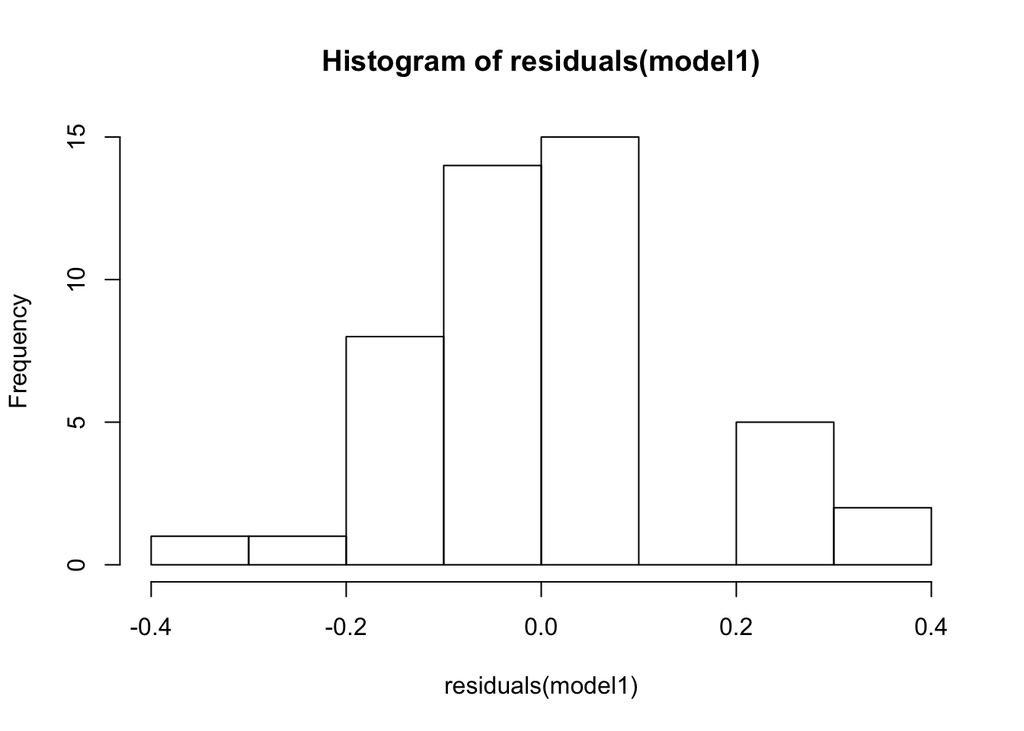

```r
hist(residuals(model1))
```

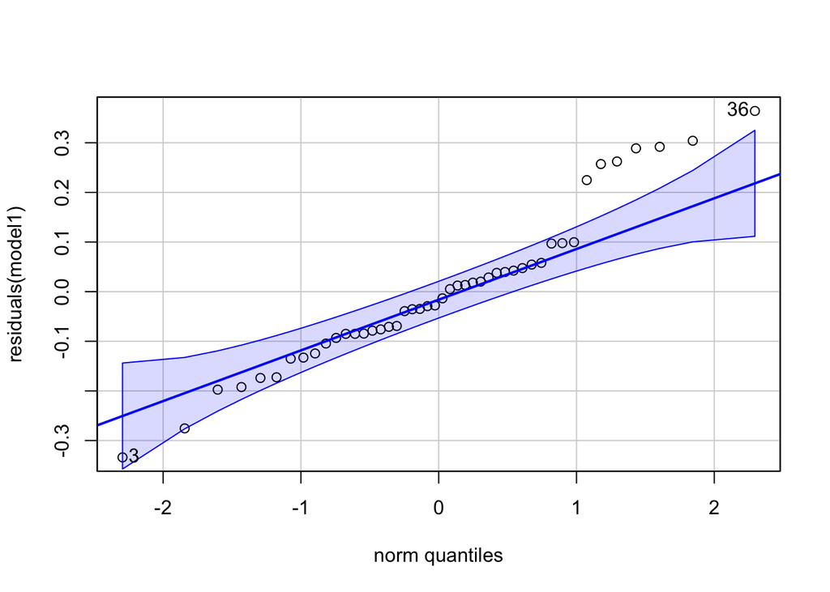

```
## [1] 36  3
```

```r
qqPlot(residuals(model1))
```

```r
leveneTest(residuals(model1)~Treatment * as.factor(Day), data=z) #passes
```

```
## Levene's Test for Homogeneity of Variance (center = median)
##       Df F value Pr(>F)
## group 11  0.8078 0.6321
##       34
```

Conduct posthoc examination of model.

```r
posthoc1<-emmeans(model1, ~Treatment|Day, adjust="Tukey") #examine posthoc comparisons for each day across treatments
cld(posthoc1)
```

```
## Day = 0:
##  Treatment emmean    SE   df lower.CL upper.CL .group
##  A          1.000 0.125 24.2   0.6802    1.320  1
##  H          1.000 0.125 24.2   0.6802    1.320  1
##  C          1.000 0.125 24.2   0.6802    1.320  1
##
## Day = 1:
##  Treatment emmean    SE   df lower.CL upper.CL .group
##  A          0.791 0.125 24.2   0.4716    1.111  1
##  C          1.075 0.167 32.8   0.6553    1.495  1
##  H          1.144 0.125 24.2   0.8242    1.464  1
##
## Day = 3:
##  Treatment emmean    SE   df lower.CL upper.CL .group
##  C          0.275 0.125 24.2  -0.0450    0.595  1
##  H          0.364 0.125 24.2   0.0445    0.684  1
##  A          0.650 0.125 24.2   0.3299    0.969  1
##
## Day = 4:
##  Treatment emmean    SE   df lower.CL upper.CL .group
##  C          0.129 0.125 24.2  -0.1909    0.449  1
##  H          0.237 0.125 24.2  -0.0824    0.557  12
##  A          0.599 0.125 24.2   0.2791    0.919   2
##
## Degrees-of-freedom method: kenward-roger
## Confidence level used: 0.95
## Conf-level adjustment: sidak method for 3 estimates
## P value adjustment: tukey method for comparing a family of 3 estimates
## significance level used: alpha = 0.05
## NOTE: Compact letter displays can be misleading
##       because they show NON-findings rather than findings.
##       Consider using 'pairs()', 'pwpp()', or 'pwpm()' instead.
```

```r
pairs(posthoc1)
```

```
## Day = 0:
##  contrast estimate    SE   df t.ratio p.value
##  A - C      0.0000 0.176 24.2   0.000  1.0000
##  A - H      0.0000 0.176 24.2   0.000  1.0000
##  C - H      0.0000 0.176 24.2   0.000  1.0000
##
## Day = 1:
##  contrast estimate    SE   df t.ratio p.value
##  A - C     -0.2837 0.208 30.2  -1.362  0.3730
##  A - H     -0.3526 0.176 24.2  -2.000  0.1338
##  C - H     -0.0689 0.208 30.2  -0.331  0.9416
##
## Day = 3:
##  contrast estimate    SE   df t.ratio p.value
##  A - C      0.3749 0.176 24.2   2.126  0.1055
##  A - H      0.2854 0.176 24.2   1.618  0.2573
##  C - H     -0.0895 0.176 24.2  -0.508  0.8683
##
## Day = 4:
##  contrast estimate    SE   df t.ratio p.value
##  A - C      0.4700 0.176 24.2   2.665  0.0348
##  A - H      0.3615 0.176 24.2   2.050  0.1218
##  C - H     -0.1084 0.176 24.2  -0.615  0.8133
##
## Degrees-of-freedom method: kenward-roger
## P value adjustment: tukey method for comparing a family of 3 estimates
```

Plot larval survival.

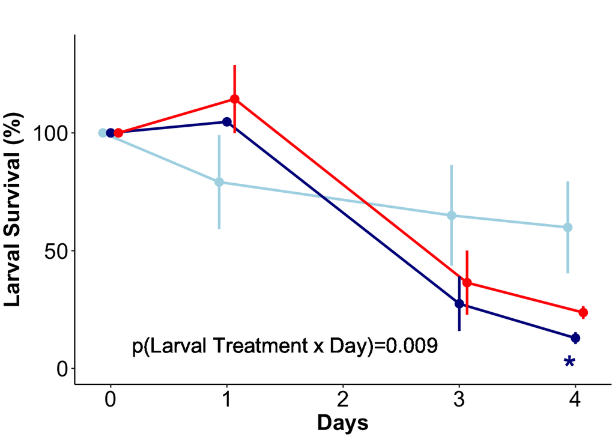

```r
#graph larval density over time
LarvalSurvPlot<-ggplot(data=larvae_surv_table, aes(x=Day, y=mean, colour=Treatment)) +
  scale_colour_manual(name="Larval Treatment",
                    values=c("lightblue", "darkblue", "red"),
                    labels=c("Ambient", "Cool", "Warm"))+
  geom_line(position=position_dodge(0.2), size=1) +
  geom_point(size=3, position=position_dodge(0.2)) +
  geom_errorbar(aes(ymin=mean-se, ymax=mean+se),
                width=0.0, size=1, position=position_dodge(0.2), linetype=1)+
  theme_classic()+
  ylim(0,135)+
  theme(text = element_text(size = 18, color="black"))+
  theme(axis.text = element_text(size = 18, color="black"))+
  theme(legend.title = element_text(size = 18, color="black", face="bold"))+
  theme(legend.text = element_text(size = 18, color="black"))+
  theme(axis.title = element_text(size = 18, color="black"))+
  theme(legend.position = "none")+
  theme(plot.margin = margin(1, 0.1, 0, 0.1, "cm")) +
  ylab(expression(bold(paste("Larval Survival (%)")))) +
  geom_text(x=1.5, y=10, label="p(Larval Treatment x Day)=0.009", size=6, color="black") +
  geom_text(x=3.95, y=0, label="*", size=10, color="darkblue") + #day4 cool
  xlab(expression(bold("Days")));LarvalSurvPlot
```

# Larval settlement

Load data for larval settlement. Calculate proportion of larvae settled in each chamber. Each chamber was loaded with a known number of larvae at the start of the settlement period. At each time point the number of spat were counted and proportion settlement is calculated as the number of settled spat at each time point divided by the number of starting larvae.

```r
#load dataset
settle<-read.csv("Data/settlement.csv", header=T, na.strings="NA") #load data

#calculate total settlement by chamber by adding the number of settlers across all three plugs in each chamber
total_settle <- plyr::ddply(settle, c("Day", "Chamber"), summarise,
                 total    = sum(Total, na.rm=TRUE),
                 aggregate = sum(Aggregate, na.rm=TRUE),
                 individual   = sum(Individual, na.rm=TRUE)
)

#merge in identifying information of tank, treatment, and number of starting larvae
total_settle$Tank<-settle$Tank[match(total_settle$Chamber, settle$Chamber)]
total_settle$Treatment<-settle$Treatment[match(total_settle$Chamber, settle$Chamber)]
total_settle$Starting.Larvae<-settle$Starting.Larvae[match(total_settle$Chamber, settle$Chamber)]

#calculate proportion setted in each chamber
total_settle$propSettled<-total_settle$total/total_settle$Starting.Larvae
total_settle$propAggregate<-total_settle$aggregate/total_settle$total
```

Generate a summary table of larval settlement over time originating from each larval treatment - settlement is shown as number of larvae settled per 100 larvae.

```r
larval_settle_table <- plyr::ddply(total_settle, c("Treatment", "Day"), summarise,
                 N    = length(total[!is.na(total)]),
                 mean = mean(total, na.rm=TRUE),
                 sd   = sd(total, na.rm=TRUE),
                 se   = sd / sqrt(N),
                 max = max(total, na.rm=TRUE),
                 lower = mean-se,
                 upper = mean+se
)
larval_settle_table
```

```
##    Treatment Day  N    mean        sd        se max     lower     upper
## 1    Ambient   1 16  3.4375  4.979541 1.2448854  19  2.192615  4.682385
## 2    Ambient   2 16  7.2500  7.549834 1.8874586  25  5.362541  9.137459
## 3    Ambient   3 16  8.5000  6.131884 1.5329710  27  6.967029 10.032971
## 4    Ambient   5 16 15.6250 11.476788 2.8691970  34 12.755803 18.494197
## 5    Ambient   6 16 10.8125  5.166801 1.2917003  23  9.520800 12.104200
## 6    Ambient   7 16 16.9375 12.577593 3.1443981  42 13.793102 20.081898
## 7       Cold   1 16  1.4375  1.672075 0.4180186   6  1.019481  1.855519
## 8       Cold   2 16  3.3750  2.125245 0.5313113   8  2.843689  3.906311
## 9       Cold   3 16  3.6875  1.740450 0.4351125   7  3.252387  4.122613
## 10      Cold   5 16  7.8750  3.896580 0.9741449  19  6.900855  8.849145
## 11      Cold   6 16  8.3750  5.097385 1.2743462  17  7.100654  9.649346
## 12      Cold   7 16 10.6875  7.436117 1.8590292  33  8.828471 12.546529
## 13      High   1 16 13.5625 12.005381 3.0013452  52 10.561155 16.563845
## 14      High   2 16 13.6875  7.115418 1.7788544  27 11.908646 15.466354
## 15      High   3 16 20.2500 15.224979 3.8062449  61 16.443755 24.056245
## 16      High   5 16 17.9375  8.225722 2.0564305  31 15.881070 19.993930
## 17      High   6 16 25.8750 11.808895 2.9522237  53 22.922776 28.827224
## 18      High   7 16 21.1250 10.892658 2.7231645  41 18.401835 23.848165
```

Analyze total settlement over time between treatments with a linear mixed model. Because this is count data we will use a poisson distribution in a glmer model. Nest chamber within tank as this is repeated measures.

Build model: `glmer(total ~ Treatment + Day + Treatment:Day + (1|Tank/Chamber), data=total_settle, family=poisson)`

```r
total_settle$Day<-as.factor(as.character(total_settle$Day))
model2<-glmer(total ~ Treatment + Day  + Treatment:Day + (1|Tank/Chamber), data=total_settle, family=poisson)
```

View model summary and significance using a Type II ANOVA analysis.

```r
summary(model2)
```

```
## Generalized linear mixed model fit by maximum likelihood (Laplace
##   Approximation) [glmerMod]
##  Family: poisson  ( log )
## Formula: total ~ Treatment + Day + Treatment:Day + (1 | Tank/Chamber)
##    Data: total_settle
##
##      AIC      BIC   logLik deviance df.resid
##   1739.7   1813.0   -849.9   1699.7      268
##
## Scaled residuals:
##     Min      1Q  Median      3Q     Max
## -3.8746 -0.6572 -0.1219  0.4798  3.3821
##
## Random effects:
##  Groups       Name        Variance Std.Dev.
##  Chamber:Tank (Intercept) 0.25710  0.5070
##  Tank         (Intercept) 0.03441  0.1855
## Number of obs: 288, groups:  Chamber:Tank, 96; Tank, 4
##
## Fixed effects:
##                    Estimate Std. Error z value Pr(>|z|)
## (Intercept)         1.09555    0.20775   5.273 1.34e-07 ***
## TreatmentCold      -0.82707    0.30593  -2.703 0.006862 **
## TreatmentHigh       1.38135    0.23544   5.867 4.43e-09 ***
## Day2                0.59887    0.24519   2.442 0.014590 *
## Day3                0.90421    0.15839   5.709 1.14e-08 ***
## Day5                1.36640    0.23569   5.797 6.73e-09 ***
## Day6                1.14499    0.15343   7.463 8.48e-14 ***
## Day7                1.44727    0.23504   6.158 7.39e-10 ***
## TreatmentCold:Day2  0.24892    0.39228   0.635 0.525732
## TreatmentHigh:Day2 -0.56513    0.31915  -1.771 0.076601 .
## TreatmentCold:Day3  0.03788    0.28994   0.131 0.896051
## TreatmentHigh:Day3 -0.50354    0.18089  -2.784 0.005374 **
## TreatmentCold:Day5  0.32866    0.37272   0.882 0.377883
## TreatmentHigh:Day5 -1.06212    0.31018  -3.424 0.000617 ***
## TreatmentCold:Day6  0.61711    0.27067   2.280 0.022610 *
## TreatmentHigh:Day6 -0.49903    0.17467  -2.857 0.004276 **
## TreatmentCold:Day7  0.55316    0.36954   1.497 0.134421
## TreatmentHigh:Day7 -0.97973    0.30884  -3.172 0.001513 **
## ---
## Signif. codes:  0 '***' 0.001 '**' 0.01 '*' 0.05 '.' 0.1 ' ' 1
## optimizer (Nelder_Mead) convergence code: 0 (OK)
## Model failed to converge with max|grad| = 0.0252073 (tol = 0.002, component 1)
```

```r
Anova(model2, type=2)
```

```
## Analysis of Deviance Table (Type II Wald chisquare tests)
##
## Response: total
##                 Chisq Df Pr(>Chisq)
## Treatment      70.035  2  6.196e-16 ***
## Day           280.524  5  < 2.2e-16 ***
## Treatment:Day  63.552 10  7.664e-10 ***
## ---
## Signif. codes:  0 '***' 0.001 '**' 0.01 '*' 0.05 '.' 0.1 ' ' 1
```

Check normality assumption for model.

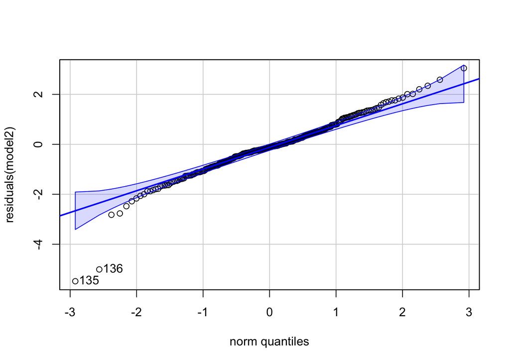

```
## [1] 135 136
```

```r
qqPlot(residuals(model2))
```

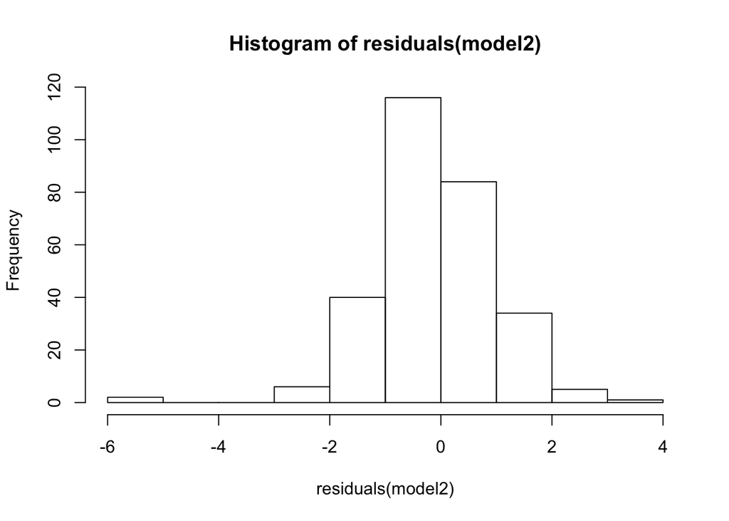

```r
hist(residuals(model2))
```

Conduct posthoc analyses to look for pairwise differences in settlement between treatments at each day.

```r
posthoc2<-emmeans(model2, ~Treatment|Day, adjust="Tukey")
cld(posthoc2)
```

```
## Day = 1:
##  Treatment emmean    SE  df asymp.LCL asymp.UCL .group
##  Cold       0.268 0.260 Inf    -0.353      0.89  1
##  Ambient    1.096 0.208 Inf     0.599      1.59   2
##  High       2.477 0.172 Inf     2.067      2.89    3
##
## Day = 2:
##  Treatment emmean    SE  df asymp.LCL asymp.UCL .group
##  Cold       1.116 0.208 Inf     0.619      1.61  1
##  Ambient    1.694 0.185 Inf     1.252      2.14   2
##  High       2.511 0.172 Inf     2.101      2.92    3
##
## Day = 3:
##  Treatment emmean    SE  df asymp.LCL asymp.UCL .group
##  Cold       1.211 0.204 Inf     0.722      1.70  1
##  Ambient    2.000 0.180 Inf     1.569      2.43   2
##  High       2.878 0.167 Inf     2.478      3.28    3
##
## Day = 5:
##  Treatment emmean    SE  df asymp.LCL asymp.UCL .group
##  Cold       1.964 0.181 Inf     1.530      2.40  1
##  Ambient    2.462 0.172 Inf     2.050      2.87  12
##  High       2.781 0.168 Inf     2.379      3.18   2
##
## Day = 6:
##  Treatment emmean    SE  df asymp.LCL asymp.UCL .group
##  Cold       2.031 0.180 Inf     1.600      2.46  1
##  Ambient    2.241 0.176 Inf     1.820      2.66  1
##  High       3.123 0.165 Inf     2.728      3.52   2
##
## Day = 7:
##  Treatment emmean    SE  df asymp.LCL asymp.UCL .group
##  Cold       2.269 0.176 Inf     1.849      2.69  1
##  Ambient    2.543 0.171 Inf     2.133      2.95  12
##  High       2.944 0.167 Inf     2.546      3.34   2
##
## Results are given on the log (not the response) scale.
## Confidence level used: 0.95
## Conf-level adjustment: sidak method for 3 estimates
## P value adjustment: tukey method for comparing a family of 3 estimates
## significance level used: alpha = 0.05
## NOTE: Compact letter displays can be misleading
##       because they show NON-findings rather than findings.
##       Consider using 'pairs()', 'pwpp()', or 'pwpm()' instead.
```

```r
pairs(posthoc2)
```

```
## Day = 1:
##  contrast       estimate    SE  df z.ratio p.value
##  Ambient - Cold    0.827 0.306 Inf   2.703  0.0188
##  Ambient - High   -1.381 0.235 Inf  -5.867  <.0001
##  Cold - High      -2.208 0.283 Inf  -7.809  <.0001
##
## Day = 2:
##  contrast       estimate    SE  df z.ratio p.value
##  Ambient - Cold    0.578 0.246 Inf   2.355  0.0486
##  Ambient - High   -0.816 0.216 Inf  -3.786  0.0004
##  Cold - High      -1.394 0.236 Inf  -5.917  <.0001
##
## Day = 3:
##  contrast       estimate    SE  df z.ratio p.value
##  Ambient - Cold    0.789 0.239 Inf   3.304  0.0027
##  Ambient - High   -0.878 0.208 Inf  -4.219  0.0001
##  Cold - High      -1.667 0.229 Inf  -7.271  <.0001
##
## Day = 5:
##  contrast       estimate    SE  df z.ratio p.value
##  Ambient - Cold    0.498 0.213 Inf   2.341  0.0503
##  Ambient - High   -0.319 0.202 Inf  -1.580  0.2543
##  Cold - High      -0.818 0.210 Inf  -3.895  0.0003
##
## Day = 6:
##  contrast       estimate    SE  df z.ratio p.value
##  Ambient - Cold    0.210 0.215 Inf   0.976  0.5920
##  Ambient - High   -0.882 0.203 Inf  -4.353  <.0001
##  Cold - High      -1.092 0.207 Inf  -5.289  <.0001
##
## Day = 7:
##  contrast       estimate    SE  df z.ratio p.value
##  Ambient - Cold    0.274 0.207 Inf   1.321  0.3832
##  Ambient - High   -0.402 0.200 Inf  -2.008  0.1102
##  Cold - High      -0.676 0.204 Inf  -3.316  0.0026
##
## Results are given on the log (not the response) scale.
## P value adjustment: tukey method for comparing a family of 3 estimates
```

Plot larval settlement rates over the settlement period for each temperature treatment.

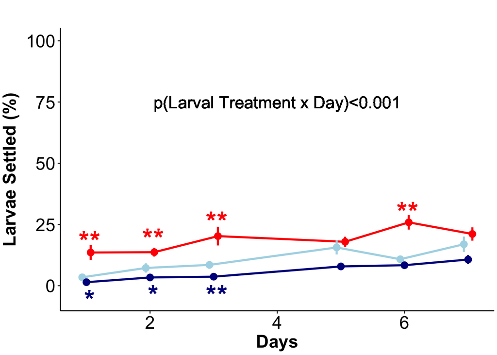

```r
#graph larval settlement over time (days 1, 2, 3, 5, 6, 7) originating from each larval treatment (ambient, cool, high)
LarvalSettlePlot<-ggplot(data=larval_settle_table, aes(x=Day, y=mean, colour=Treatment)) +
  scale_colour_manual(name="Larval Treatment",
                       values=c("lightblue", "darkblue", "red"),
                       labels=c("Ambient", "Cool", "Warm"))+
  geom_line(position=position_dodge(0.2), size=1) +
  geom_point(size=3, position=position_dodge(0.2)) +
  geom_errorbar(aes(ymin=mean-se, ymax=mean+se),
                width=0.0, size=1, position=position_dodge(0.2), linetype=1)+
  theme_classic()+
  ylim(-5,100)+
  theme(text = element_text(size = 18, color="black"))+
  theme(axis.text = element_text(size = 18, color="black"))+
  theme(legend.text = element_text(size = 18, color="black"))+
  theme(legend.position = "none")+
  theme(legend.title = element_text(size = 18, color="black", face="bold"))+
  theme(axis.title = element_text(size = 18, color="black"))+
  theme(plot.margin = margin(1, 0.1, 0, 0.1, "cm")) +
  ylab(expression(bold(paste("Larvae Settled (%)")))) +
  geom_text(x=4, y=75, label="p(Larval Treatment x Day)<0.001", size=6, color="black") + #obtained from analysis below
  geom_text(x=1.05, y=18, label="**", size=10, color="red") + #day1 high
  geom_text(x=1.05, y=-6, label="*", size=10, color="darkblue") + #day1 cool
  geom_text(x=2.05, y=19, label="**", size=10, color="red") + #day2 high
  geom_text(x=2.05, y=-4, label="*", size=10, color="darkblue") + #day2 high
  geom_text(x=3.05, y=26, label="**", size=10, color="red") + #day3 high
  geom_text(x=3.05, y=-4, label="**", size=10, color="darkblue") + #day3 cool
  geom_text(x=6.05, y=30, label="**", size=10, color="red") + #day6 high
  xlab(expression(bold("Days"))); LarvalSettlePlot
```

# Spat survival

Load data for spat survival. Calculate percent spat survival as the number of spat alive at each timepoint divided by the number of spat alive at the start of the experiment.

In this analysis, the number of spat alive at each time point is recorded as the number of “successes”. The number of larvae that died are “failures”. Recruits are tracked by “plug ID”. Note that spat are referred to as “recruits” in the code, but spat is used in revised manuscript.

```r
#load and manipulate data
recruits<-read.csv("Data/surv_recruits.csv", header=T, na.strings="NA") #load recruit survivorship dataset
recruits$Tank<-as.factor(recruits$Tank)

#calculate proportion survival
recruits$proportion<-(recruits$Success/(recruits$Success+recruits$Failure))*100 #calculate number alive (successes) at each time point divided by the total number of starting recruits (successes + failures).

#add in larval temperature treatment information - plug 98 did not have larval treatment information and was removed
recruits$Larval.Treatment<-settle$Treatment[match(recruits$Plug.ID, settle$Plug)]
```

```r
recruit_surv_table <- plyr::ddply(recruits, c("Days", "Juv.Treatment", "Larval.Treatment"), summarise,
                           N    = length(proportion[!is.na(proportion)]),
                           mean = mean(proportion, na.rm=TRUE),
                           sd   = sd(proportion, na.rm=TRUE),
                           se   = sd / sqrt(N),
                           max = max(proportion, na.rm=TRUE),
                           lower = mean-se,
                           upper = mean+se
);recruit_surv_table
```

```
##    Days Juv.Treatment Larval.Treatment  N      mean        sd        se max
## 1     1       Ambient          Ambient 45 100.00000  0.000000 0.0000000 100
## 2     1       Ambient             Cold 40 100.00000  0.000000 0.0000000 100
## 3     1       Ambient             High 47 100.00000  0.000000 0.0000000 100
## 4     1          High          Ambient 38 100.00000  0.000000 0.0000000 100
## 5     1          High             Cold 41 100.00000  0.000000 0.0000000 100
## 6     1          High             High 44 100.00000  0.000000 0.0000000 100
## 7    11       Ambient          Ambient 45  98.84710  5.023557 0.7488677 100
## 8    11       Ambient             Cold 40  95.98363 16.564109 2.6190155 100
## 9    11       Ambient             High 47  96.74097 10.471895 1.5274828 100
## 10   11          High          Ambient 38  97.73994  8.761869 1.4213628 100
## 11   11          High             Cold 41  98.64499  6.183971 0.9657740 100
## 12   11          High             High 44  99.60543  1.902685 0.2868406 100
## 13   14       Ambient          Ambient 45  97.37797  7.622030 1.1362252 100
## 14   14       Ambient             Cold 40  95.60035 16.436013 2.5987618 100
```

[output cut: 59 more lines]

```r
recruit_surv_table2 <- plyr::ddply(recruits, c("Days", "Juv.Treatment", "Tank"), summarise,
                                  N    = length(proportion[!is.na(proportion)]),
                                  mean = mean(proportion, na.rm=TRUE),
                                  sd   = sd(proportion, na.rm=TRUE),
                                  se   = sd / sqrt(N),
                                  max = max(proportion, na.rm=TRUE),
                                  lower = mean-se,
                                  upper = mean+se
);recruit_surv_table2
```

```
##    Days Juv.Treatment Tank  N      mean        sd        se max     lower
## 1     1       Ambient    2 67 100.00000  0.000000 0.0000000 100 100.00000
## 2     1       Ambient    3 65 100.00000  0.000000 0.0000000 100 100.00000
## 3     1          High    1 61 100.00000  0.000000 0.0000000 100 100.00000
## 4     1          High    4 62 100.00000  0.000000 0.0000000 100 100.00000
## 5    11       Ambient    2 67  96.91075  8.910885 1.0886379 100  95.82212
## 6    11       Ambient    3 65  97.55800 13.573740 1.6836152 100  95.87438
## 7    11          High    1 61  99.28962  3.382555 0.4330918 100  98.85653
## 8    11          High    4 62  98.13765  7.964818 1.0115329 100  97.12612
## 9    14       Ambient    2 67  96.20100  9.591920 1.1718396 100  95.02916
## 10   14       Ambient    3 65  96.01099 14.349836 1.7798781 100  94.23111
## 11   14          High    1 61  98.67942  5.016602 0.6423101 100  98.03711
## 12   14          High    4 63  97.62299  8.186456 1.0313965 100  96.59160
## 13   21       Ambient    2 65  95.79339  8.815487 1.0934266 100  94.69997
## 14   21       Ambient    3 65  95.47253 14.687187 1.8217214 100  93.65081
```

[output cut: 35 more lines]

Analyze spat survival over time between treatments with a binomial mixed model with a success and failure vector. Plug included as a random effect due to repeated measures.

Build model for spat survival: `glmer(y~Juv.Treatment * Larval.Treatment * Days + (1|Tank/Plug.ID), family=binomial, data=recruits)`

```r
recruits$Days<-as.factor(as.character(recruits$Days))
attach(recruits)

y<-cbind(Success, Failure) #generate binomial vector

model3<-glmer(y~Juv.Treatment * Larval.Treatment * Days + (1|Tank/Plug.ID), family=binomial, data=recruits)

detach(recruits)
```

View summary of model and significance with a Type II ANOVA analysis.

```r
summary(model3)
```

```
## Generalized linear mixed model fit by maximum likelihood (Laplace
##   Approximation) [glmerMod]
##  Family: binomial  ( logit )
## Formula: y ~ Juv.Treatment * Larval.Treatment * Days + (1 | Tank/Plug.ID)
##    Data: recruits
##
##      AIC      BIC   logLik deviance df.resid
##   1664.8   1871.4   -794.4   1588.8     1660
##
## Scaled residuals:
##     Min      1Q  Median      3Q     Max
## -3.8884  0.0000  0.1518  0.3188  2.5587
##
## Random effects:
##  Groups       Name        Variance  Std.Dev.
##  Plug.ID:Tank (Intercept) 1.327e+00 1.152e+00
##  Tank         (Intercept) 1.326e-09 3.642e-05
## Number of obs: 1698, groups:  Plug.ID:Tank, 285; Tank, 4
##
## Fixed effects:
##                                                 Estimate Std. Error z value
## (Intercept)                                     22.14341 2518.71020   0.009
## Juv.TreatmentHigh                               -0.20608 3943.32812   0.000
## Larval.TreatmentCold                            -0.01606 3823.43708   0.000
## Larval.TreatmentHigh                             0.26972 3510.60814   0.000
## Days11                                         -18.03412 2518.71021  -0.007
## Days14                                         -18.42226 2518.71020  -0.007
## Days21                                         -18.67341 2518.71020  -0.007
## Days28                                         -18.97341 2518.71020  -0.008
## Days47                                         -19.66560 2518.71020  -0.008
## Juv.TreatmentHigh:Larval.TreatmentCold          -0.35155 5745.25348   0.000
## Juv.TreatmentHigh:Larval.TreatmentHigh          -0.35878 5402.88418   0.000
## Juv.TreatmentHigh:Days11                         0.64004 3943.32815   0.000
## Juv.TreatmentHigh:Days14                         0.44674 3943.32813   0.000
## Juv.TreatmentHigh:Days21                         0.41486 3943.32813   0.000
## Juv.TreatmentHigh:Days28                        -0.27238 3943.32812   0.000
## Juv.TreatmentHigh:Days47                        -1.83956 3943.32811   0.000
## Larval.TreatmentCold:Days11                      0.01090 3823.43709   0.000
## Larval.TreatmentHigh:Days11                     -0.07303 3510.60816   0.000
## Larval.TreatmentCold:Days14                      0.14713 3823.43709   0.000
```

[output cut: 41 more lines]

```
## Larval.TreatmentHigh:Days28                      1.000
## Larval.TreatmentCold:Days47                      1.000
## Larval.TreatmentHigh:Days47                      1.000
## Juv.TreatmentHigh:Larval.TreatmentCold:Days11    1.000
## Juv.TreatmentHigh:Larval.TreatmentHigh:Days11    1.000
## Juv.TreatmentHigh:Larval.TreatmentCold:Days14    1.000
## Juv.TreatmentHigh:Larval.TreatmentHigh:Days14    1.000
## Juv.TreatmentHigh:Larval.TreatmentCold:Days21    1.000
## Juv.TreatmentHigh:Larval.TreatmentHigh:Days21    1.000
## Juv.TreatmentHigh:Larval.TreatmentCold:Days28    1.000
## Juv.TreatmentHigh:Larval.TreatmentHigh:Days28    1.000
## Juv.TreatmentHigh:Larval.TreatmentCold:Days47    1.000
## Juv.TreatmentHigh:Larval.TreatmentHigh:Days47    1.000
## optimizer (Nelder_Mead) convergence code: 0 (OK)
## boundary (singular) fit: see ?isSingular
```

```r
Anova(model3, type=2)
```

```
## Analysis of Deviance Table (Type II Wald chisquare tests)
##
## Response: y
##                                        Chisq Df Pr(>Chisq)
## Juv.Treatment                       143.0241 15  < 2.2e-16 ***
## Larval.Treatment                      9.0293 20     0.9826
## Days                                596.6685 25  < 2.2e-16 ***
## Juv.Treatment:Larval.Treatment        4.6784 10     0.9116
## Juv.Treatment:Days                  101.0050 13  1.059e-15 ***
## Larval.Treatment:Days                 7.2062 18     0.9883
## Juv.Treatment:Larval.Treatment:Days   4.3484 10     0.9303
## ---
## Signif. codes:  0 '***' 0.001 '**' 0.01 '*' 0.05 '.' 0.1 ' ' 1
```

Run posthoc analysis to look at differences between spat treatments for each day because day*spat treatment was significant, with no effect of larval treatment.

```r
posthoc3<-emmeans(model3, ~Juv.Treatment|Days, adjust="Tukey")
cld(posthoc3)
```

```
## Days = 1:
##  Juv.Treatment emmean       SE  df asymp.LCL asymp.UCL .group
##  High          21.785 1701.311 Inf -3783.156  3826.727  1
##  Ambient       22.228 1512.876 Inf -3361.283  3405.739  1
##
## Days = 11:
##  Juv.Treatment emmean       SE  df asymp.LCL asymp.UCL .group
##  Ambient        4.173    0.242 Inf     3.631     4.715  1
##  High           4.816    0.388 Inf     3.949     5.683  1
##
## Days = 14:
##  Juv.Treatment emmean       SE  df asymp.LCL asymp.UCL .group
##  Ambient        3.837    0.221 Inf     3.343     4.332  1
##  High           4.250    0.335 Inf     3.502     4.999  1
##
## Days = 21:
##  Juv.Treatment emmean       SE  df asymp.LCL asymp.UCL .group
##  High           3.484    0.241 Inf     2.946     4.023  1
##  Ambient        3.606    0.212 Inf     3.132     4.079  1
##
## Days = 28:
##  Juv.Treatment emmean       SE  df asymp.LCL asymp.UCL .group
##  High           2.504    0.182 Inf     2.097     2.911  1
##  Ambient        3.263    0.195 Inf     2.828     3.698   2
##
## Days = 47:
##  Juv.Treatment emmean       SE  df asymp.LCL asymp.UCL .group
##  High           0.308    0.143 Inf    -0.011     0.627  1
##  Ambient        2.471    0.169 Inf     2.095     2.848   2
##
## Results are averaged over the levels of: Larval.Treatment
## Results are given on the logit (not the response) scale.
## Confidence level used: 0.95
## Conf-level adjustment: sidak method for 2 estimates
## Results are given on the log odds ratio (not the response) scale.
## significance level used: alpha = 0.05
## NOTE: Compact letter displays can be misleading
##       because they show NON-findings rather than findings.
##       Consider using 'pairs()', 'pwpp()', or 'pwpm()' instead.
```

```r
pairs(posthoc3)
```

```
## Days = 1:
##  contrast       estimate       SE  df z.ratio p.value
##  Ambient - High    0.443 2276.675 Inf   0.000  0.9998
##
## Days = 11:
##  contrast       estimate       SE  df z.ratio p.value
##  Ambient - High   -0.643    0.457 Inf  -1.406  0.1596
##
## Days = 14:
##  contrast       estimate       SE  df z.ratio p.value
##  Ambient - High   -0.413    0.401 Inf  -1.029  0.3035
##
## Days = 21:
##  contrast       estimate       SE  df z.ratio p.value
##  Ambient - High    0.121    0.321 Inf   0.379  0.7050
##
## Days = 28:
##  contrast       estimate       SE  df z.ratio p.value
##  Ambient - High    0.759    0.266 Inf   2.851  0.0044
##
## Days = 47:
##  contrast       estimate       SE  df z.ratio p.value
##  Ambient - High    2.164    0.221 Inf   9.797  <.0001
##
## Results are averaged over the levels of: Larval.Treatment
## Results are given on the log odds ratio (not the response) scale.
```

Check dispersion assumption.

```r
dispersion_glmer(model3) #no evidence of overdispersion as value is <1.4
```

```
## [1] 0.6213057
```

We now need to account for the effect of colony type (individual vs aggregate) on survival. We found variation in settlement behavior with spat settling both as individuals and aggregates of multiple larvae. The number of aggregates and individuals was recorded and the survival of each individual tracked.

The success and failure columns reflect the total survival (aggregates + individuals). Generate a new success and failure column for individuals and aggregates separately. Display mean proportion aggregation for each treatment combination.

```r
#success is the number of alive colonies (Ind or Agg columns)
#failure is the number of starting alive colonies - number of alive colonies at a given time point
agg_ind<-recruits%>%
  mutate(Success_Ind=Individual)%>%
  mutate(Success_Agg=Aggregate)%>%
  group_by(Plug.ID)%>%
  arrange(Plug.ID)%>%
  mutate(Failure_Ind=lag(first(Success_Ind), default = first(Success_Ind))-Success_Ind)%>%
  mutate(Failure_Agg=lag(first(Success_Agg), default = first(Success_Agg))-Success_Agg)

#calculate proportion of colonies that are aggregates for these plugs
agg_ind<-agg_ind%>%
  mutate(prop_agg=Aggregate/Total)

agg_summary<-agg_ind%>%
  group_by(Juv.Treatment, Larval.Treatment)%>%
  summarise(mean=mean(prop_agg, na.rm=TRUE));agg_summary
```

```
## # A tibble: 6 × 3
## # Groups:   Juv.Treatment [2]
##   Juv.Treatment Larval.Treatment   mean
##   <fct>         <fct>             <dbl>
## 1 Ambient       Ambient          0.0780
## 2 Ambient       Cold             0.0798
## 3 Ambient       High             0.124
## 4 High          Ambient          0.107
## 5 High          Cold             0.0608
## 6 High          High             0.118
```

```r
plug_summary<-agg_ind%>%
  group_by(Plug.ID)%>%
  summarise(mean=mean(prop_agg, na.rm=TRUE))%>%
  filter(!is.na(mean))
```

View distribution of proportion aggregation.

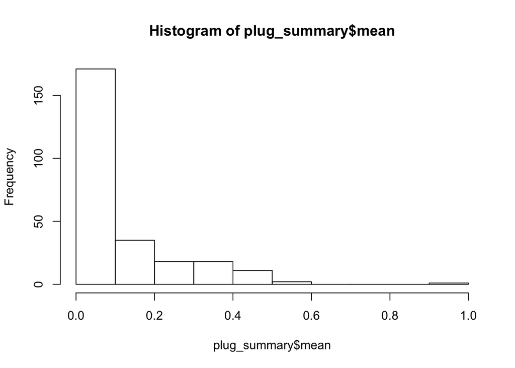

```r
hist(plug_summary$mean)
```

There are clear outliers in the histogram for proportion aggregation. Look at distrubution of plugs by proportion aggregation.

```r
n=sum(with(plug_summary, mean<0.5))
d=sum(with(plug_summary, mean<1))
n/d
```

```
## [1] 0.972549
```

```r
n=sum(with(plug_summary, mean<0.2))
d=sum(with(plug_summary, mean<1))
n/d
```

```
## [1] 0.8039216
```

```r
n=sum(with(plug_summary, mean<0.1))
d=sum(with(plug_summary, mean<1))
n/d
```

```
## [1] 0.6666667
```

97% of plugs have <50% aggregates  
80% of plugs have <20% aggregates  
67% of plugs have <10% aggregates

A majority of plugs have <10% aggregates. Because 97% of plugs have <50% aggregates, we will remove any plugs with >50% aggregation.

```r
agg_ind<-agg_ind%>%
  filter(prop_agg<0.5)
```

Test for differences in aggregation by treatments.

```r
summary(aov(prop_agg~Juv.Treatment*Larval.Treatment, data=agg_ind))
```

```
##                                  Df Sum Sq Mean Sq F value  Pr(>F)
## Juv.Treatment                     1  0.031 0.03112   2.593 0.10753
## Larval.Treatment                  2  0.151 0.07537   6.282 0.00192 **
## Juv.Treatment:Larval.Treatment    2  0.078 0.03917   3.265 0.03850 *
## Residuals                      1412 16.942 0.01200
## ---
## Signif. codes:  0 '***' 0.001 '**' 0.01 '*' 0.05 '.' 0.1 ' ' 1
```

There is a significant effect of treatment on aggregation, therefore this needs to be accounted for in our analysis. Because our experimental design was not designed to examine aggregate vs individual dynamics, we will account for aggregation as a random effect in our modeling. Model structure will be the same as previous model, but with the added random effect of proportion aggregation for each replicate (plug).

Model: `glmer(y~Juv.Treatment * Larval.Treatment * Days + (1|Tank/Plug.ID) + (1|prop_agg), family=binomial, data=agg_ind)`

```r
agg_ind$Days<-as.factor(as.character(agg_ind$Days))
attach(agg_ind)

y<-cbind(Success, Failure)

model4<-glmer(y~Juv.Treatment * Larval.Treatment * Days + (1|Tank/Plug.ID) + (1|prop_agg), family=binomial, data=agg_ind)

detach(agg_ind)
```

View summary of model and significance with a Type II ANOVA analysis.

```r
summary(model4)
```

```
## Generalized linear mixed model fit by maximum likelihood (Laplace
##   Approximation) [glmerMod]
##  Family: binomial  ( logit )
## Formula: y ~ Juv.Treatment * Larval.Treatment * Days + (1 | Tank/Plug.ID) +
##     (1 | prop_agg)
##    Data: agg_ind
##
##      AIC      BIC   logLik deviance df.resid
##   1500.8   1705.8   -711.4   1422.8     1378
##
## Scaled residuals:
##     Min      1Q  Median      3Q     Max
## -3.5803  0.0000  0.1957  0.3484  2.3885
##
## Random effects:
##  Groups       Name        Variance Std.Dev.
##  Plug.ID:Tank (Intercept) 0.92306  0.9608
##  prop_agg     (Intercept) 0.33618  0.5798
##  Tank         (Intercept) 0.01249  0.1117
## Number of obs: 1417, groups:  Plug.ID:Tank, 249; prop_agg, 36; Tank, 4
##
## Fixed effects:
##                                                 Estimate Std. Error z value
## (Intercept)                                    2.227e+01  2.678e+03   0.008
## Juv.TreatmentHigh                             -3.588e-01  4.247e+03   0.000
## Larval.TreatmentCold                          -1.617e-01  3.977e+03   0.000
## Larval.TreatmentHigh                          -1.813e-02  3.770e+03   0.000
## Days11                                        -1.810e+01  2.678e+03  -0.007
## Days14                                        -1.848e+01  2.678e+03  -0.007
## Days21                                        -1.870e+01  2.678e+03  -0.007
## Days28                                        -1.927e+01  2.678e+03  -0.007
## Days47                                        -1.984e+01  2.678e+03  -0.007
## Juv.TreatmentHigh:Larval.TreatmentCold        -1.294e-01  6.080e+03   0.000
## Juv.TreatmentHigh:Larval.TreatmentHigh         8.352e-03  5.802e+03   0.000
## Juv.TreatmentHigh:Days11                       1.013e+00  4.247e+03   0.000
## Juv.TreatmentHigh:Days14                       6.428e-01  4.247e+03   0.000
## Juv.TreatmentHigh:Days21                       5.346e-01  4.247e+03   0.000
## Juv.TreatmentHigh:Days28                       9.610e-02  4.247e+03   0.000
## Juv.TreatmentHigh:Days47                      -1.522e+00  4.247e+03   0.000
## Larval.TreatmentCold:Days11                    2.701e-01  3.977e+03   0.000
```

[output cut: 44 more lines]

```
## Larval.TreatmentCold:Days47                      1.000
## Larval.TreatmentHigh:Days47                      1.000
## Juv.TreatmentHigh:Larval.TreatmentCold:Days11    1.000
## Juv.TreatmentHigh:Larval.TreatmentHigh:Days11    1.000
## Juv.TreatmentHigh:Larval.TreatmentCold:Days14    1.000
## Juv.TreatmentHigh:Larval.TreatmentHigh:Days14    1.000
## Juv.TreatmentHigh:Larval.TreatmentCold:Days21    1.000
## Juv.TreatmentHigh:Larval.TreatmentHigh:Days21    1.000
## Juv.TreatmentHigh:Larval.TreatmentCold:Days28    1.000
## Juv.TreatmentHigh:Larval.TreatmentHigh:Days28    1.000
## Juv.TreatmentHigh:Larval.TreatmentCold:Days47    1.000
## Juv.TreatmentHigh:Larval.TreatmentHigh:Days47    1.000
## optimizer (Nelder_Mead) convergence code: 0 (OK)
## unable to evaluate scaled gradient
## Model failed to converge: degenerate  Hessian with 5 negative eigenvalues
```

```r
Anova(model4, type=2)
```

```
## Analysis of Deviance Table (Type II Wald chisquare tests)
##
## Response: y
##                                        Chisq Df Pr(>Chisq)
## Juv.Treatment                       106.9890 15  6.089e-16 ***
## Larval.Treatment                     12.2590 20     0.9069
## Days                                479.0207 25  < 2.2e-16 ***
## Juv.Treatment:Larval.Treatment        4.3325 10     0.9311
## Juv.Treatment:Days                   74.3066 13  1.281e-10 ***
## Larval.Treatment:Days                 8.1960 18     0.9756
## Juv.Treatment:Larval.Treatment:Days   3.1423 10     0.9779
## ---
## Signif. codes:  0 '***' 0.001 '**' 0.01 '*' 0.05 '.' 0.1 ' ' 1
```

Results show the same significant effects as the previous model - spat treatment and day interaction is significant.

Examine posthoc differences between spat treatments at each day.

```r
posthoc4<-emmeans(model4, ~Juv.Treatment|Days, adjust="Tukey")
cld(posthoc4)
```

```
## Days = 1:
##  Juv.Treatment emmean       SE  df asymp.LCL asymp.UCL .group
##  High          21.810 1817.683 Inf -4043.396  4087.016  1
##  Ambient       22.209 1593.640 Inf -3541.929  3586.348  1
##
## Days = 11:
##  Juv.Treatment emmean       SE  df asymp.LCL asymp.UCL .group
##  Ambient        4.419    0.312 Inf     3.720     5.118  1
##  High           4.894    0.432 Inf     3.928     5.860  1
##
## Days = 14:
##  Juv.Treatment emmean       SE  df asymp.LCL asymp.UCL .group
##  Ambient        4.014    0.283 Inf     3.381     4.646  1
##  High           4.331    0.377 Inf     3.489     5.174  1
##
## Days = 21:
##  Juv.Treatment emmean       SE  df asymp.LCL asymp.UCL .group
##  High           3.615    0.303 Inf     2.937     4.293  1
##  Ambient        3.765    0.271 Inf     3.159     4.371  1
##
## Days = 28:
##  Juv.Treatment emmean       SE  df asymp.LCL asymp.UCL .group
##  High           2.592    0.250 Inf     2.033     3.150  1
##  Ambient        3.317    0.251 Inf     2.755     3.879   2
##
## Days = 47:
##  Juv.Treatment emmean       SE  df asymp.LCL asymp.UCL .group
##  High           0.463    0.238 Inf    -0.069     0.995  1
##  Ambient        2.566    0.234 Inf     2.042     3.090   2
##
## Results are averaged over the levels of: Larval.Treatment
## Results are given on the logit (not the response) scale.
## Confidence level used: 0.95
## Conf-level adjustment: sidak method for 2 estimates
## Results are given on the log odds ratio (not the response) scale.
## significance level used: alpha = 0.05
## NOTE: Compact letter displays can be misleading
##       because they show NON-findings rather than findings.
##       Consider using 'pairs()', 'pwpp()', or 'pwpm()' instead.
```

```r
pairs(posthoc4)
```

```
## Days = 1:
##  contrast       estimate       SE  df z.ratio p.value
##  Ambient - High    0.399 2417.367 Inf   0.000  0.9999
##
## Days = 11:
##  contrast       estimate       SE  df z.ratio p.value
##  Ambient - High   -0.475    0.494 Inf  -0.961  0.3364
##
## Days = 14:
##  contrast       estimate       SE  df z.ratio p.value
##  Ambient - High   -0.318    0.424 Inf  -0.749  0.4539
##
## Days = 21:
##  contrast       estimate       SE  df z.ratio p.value
##  Ambient - High    0.150    0.348 Inf   0.430  0.6671
##
## Days = 28:
##  contrast       estimate       SE  df z.ratio p.value
##  Ambient - High    0.725    0.286 Inf   2.537  0.0112
##
## Days = 47:
##  contrast       estimate       SE  df z.ratio p.value
##  Ambient - High    2.103    0.244 Inf   8.606  <.0001
##
## Results are averaged over the levels of: Larval.Treatment
## Results are given on the log odds ratio (not the response) scale.
```

Examine dispersion assumption.

```r
dispersion_glmer(model4) #no evidence of overdispersion as value is <1.4
```

```
## [1] 0.6344161
```

Graph proportion survival over time in spat

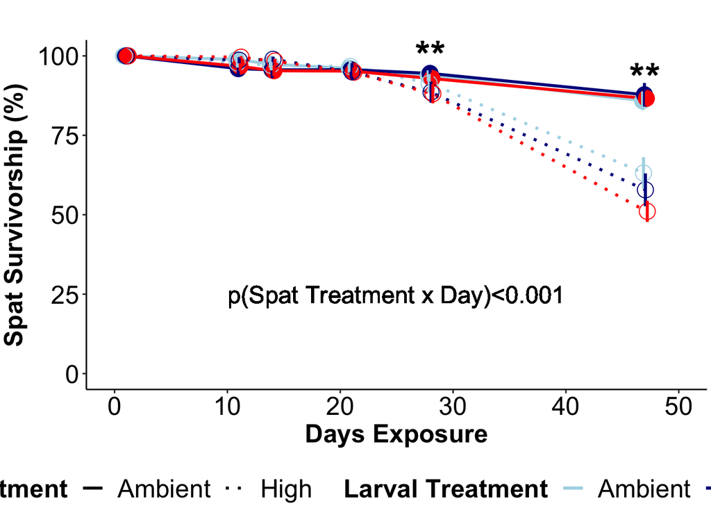

```r
RecruitSurvPlot<-ggplot(data=recruit_surv_table, aes(x=Days, y=mean, shape=Juv.Treatment, linetype=Juv.Treatment, colour=Larval.Treatment, group=interaction(Juv.Treatment, Larval.Treatment))) +
  scale_colour_manual(name="Larval Treatment",
                      values=c("lightblue", "darkblue", "red"),
                      labels=c("Ambient", "Cool", "Warm"))+
  geom_line(position=position_dodge(0.3), size=1) +
  geom_point(size=5, position=position_dodge(0.5), show.legend=FALSE) +
  geom_errorbar(aes(ymin=mean-se, ymax=mean+se),
                width=0.0, size=1, position=position_dodge(0.5), linetype=1)+
  scale_linetype_manual(name="Spat Treatment", values=c("solid", "dotted"), labels=c("Ambient", "High"))+
  scale_shape_manual(name="Spat Treatment", values=c(19,21))+
  theme_classic()+
  ylim(0,100)+
  xlim(0,50)+
  theme(text = element_text(size = 18, color="black"))+
  theme(axis.text = element_text(size = 18, color="black"))+
  theme(legend.title = element_text(size = 18, color="black", face="bold"))+
  theme(legend.text = element_text(size = 18, color="black"))+
  theme(axis.title = element_text(size = 18, color="black"))+
  theme(legend.position = "bottom")+
  ylab(expression(bold(paste("Spat Survivorship (%)")))) +
  theme(plot.margin = margin(1, 0.1, 0, 0.1, "cm")) +
  geom_text(x=28, y=100, label="**", size=10, color="black") +
  geom_text(x=47, y=93, label="**", size=10, color="black") +
  geom_text(x=25, y=25, label="p(Spat Treatment x Day)<0.001", size=6, color="black") +
  xlab(expression(bold("Days Exposure")));RecruitSurvPlot
```

# Generate final figure

```r
#generate figure with larval survival, settlement, and recruit survival in one panel

figure_surv<-plot_grid(LarvalSurvPlot, LarvalSettlePlot, labels = c("a", "b"), ncol=2, nrow=1, rel_heights= c(1,1), rel_widths = c(1,1), label_size = 20, label_y=1, align="h")

figure_surv_b<-plot_grid(figure_surv, RecruitSurvPlot, labels = c("", "c"), ncol=1, nrow=2, rel_heights= c(1,1), rel_widths = c(1,1), label_size = 20, label_y=1)

ggsave(filename="Figures/DataFigure.pdf", plot=figure_surv_b, dpi=500, width=12, height=10, units="in")
ggsave(filename="Figures/DataFigure.png", plot=figure_surv_b, dpi=500, width=12, height=10, units="in")
```